# Machine Learning Project

Jason Sklikas

13 May 2017

## Machine Learning Project

### Introduction

Using devices such as Jawbone Up, Nike FuelBand, and Fitbit it is now possible to collect a large amount of data about personal activity relatively inexpensively. These type of devices are part of the quantified self movement a group of enthusiasts who take measurements about themselves regularly to improve their health, to find patterns in their behavior, or because they are tech geeks. One thing that people regularly do is quantify how much of a particular activity they do, but they rarely quantify how well they do it. In this project, your goal will be to use data from accelerometers on the belt, forearm, arm, and dumbell of 6 participants. They were asked to perform barbell lifts correctly and incorrectly in 5 different ways.

Goal The goal of this project is to predict the manner in which they did the exercise. This is the “classe” variable in the training set. You may use any of the other variables to predict with. You should create a report describing how you built your model, how you used cross validation, what you think the expected out of sample error is, and why you made the choices you did. You will also use your prediction model to predict 20 different test cases.

### Loading and Cleaning Data

We are going to load the data adding NA where the cells were empty.

```r
library(caret)
```

```r
library(rpart.plot)
library(rattle)
library(rpart)
library(randomForest)
testing<- read.csv("pml-testing.csv",na.strings = c("NA", ""))
training <- read.csv("pml-training.csv",na.strings = c("NA", ""))

training <- training[, colSums(is.na(training)) == 0]
testing <- testing[, colSums(is.na(testing)) == 0]

trainData <- training[,-c(1:6)]
testData <- testing[, -c(1:6)]
```

From our training and test set we remove the first six columns because they will not help us in our predictions.

```r
set.seed(9526)
inTrain <- createDataPartition(trainData$classe, p = 0.6, list = FALSE)
mytrain <- trainData[inTrain, ]
mytest <- trainData[-inTrain, ]
```

### Prediction Algoriths

```r
fit_rpart <- train(classe ~ ., data = mytrain, method = "rpart")
fit_rpart
```

```
## CART
##
## 11776 samples
##    53 predictor
##     5 classes: 'A', 'B', 'C', 'D', 'E'
##
## No pre-processing
## Resampling: Bootstrapped (25 reps)
## Summary of sample sizes: 11776, 11776, 11776, 11776, 11776, 11776, ...
## Resampling results across tuning parameters:
##
##   cp          Accuracy   Kappa
##   0.04057902  0.5060916  0.35212348
##   0.04322892  0.4674697  0.29176052
##   0.11627907  0.3328218  0.07441509
##
## Accuracy was used to select the optimal model using  the largest value.
## The final value used for the model was cp = 0.04057902.
```

[figure not shown]

```r
fancyRpartPlot(fit_rpart$finalModel)
```

```r
predict_rpart <- predict(fit_rpart, mytest)
conf_rpart <- confusionMatrix(mytest$classe, predict_rpart)
conf_rpart
```

```
## Confusion Matrix and Statistics
##
##           Reference
## Prediction    A    B    C    D    E
##          A 1995   43  190    0    4
##          B  652  479  387    0    0
##          C  207   58 1103    0    0
##          D  401  199  627    0   59
##          E   89  271  216    0  866
##
## Overall Statistics
##
##                Accuracy : 0.5663
##                  95% CI : (0.5552, 0.5773)
##     No Information Rate : 0.4262
##     P-Value [Acc > NIR] : < 2.2e-16
##
##                   Kappa : 0.4404
##  Mcnemar's Test P-Value : < 2.2e-16
##
## Statistics by Class:
##
##                      Class: A Class: B Class: C Class: D Class: E
## Sensitivity            0.5966  0.45619   0.4372       NA   0.9322
## Specificity            0.9474  0.84712   0.9502   0.8361   0.9167
## Pos Pred Value         0.8938  0.31555   0.8063       NA   0.6006
## Neg Pred Value         0.7597  0.90977   0.7808       NA   0.9902
## Prevalence             0.4262  0.13383   0.3216   0.0000   0.1184
## Detection Rate         0.2543  0.06105   0.1406   0.0000   0.1104
## Detection Prevalence   0.2845  0.19347   0.1744   0.1639   0.1838
## Balanced Accuracy      0.7720  0.65165   0.6937       NA   0.9245
```

### RM Method

```r
fit_rf<-randomForest(classe ~ ., data=mytrain)
print(fit_rf, digits = 4)
```

```
##
## Call:
##  randomForest(formula = classe ~ ., data = mytrain)
##                Type of random forest: classification
##                      Number of trees: 500
## No. of variables tried at each split: 7
##
##         OOB estimate of  error rate: 0.33%
## Confusion matrix:
##      A    B    C    D    E  class.error
## A 3345    3    0    0    0 0.0008960573
## B    5 2273    1    0    0 0.0026327337
## C    0   11 2043    0    0 0.0053554041
## D    0    0   12 1916    2 0.0072538860
## E    0    0    0    5 2160 0.0023094688
```

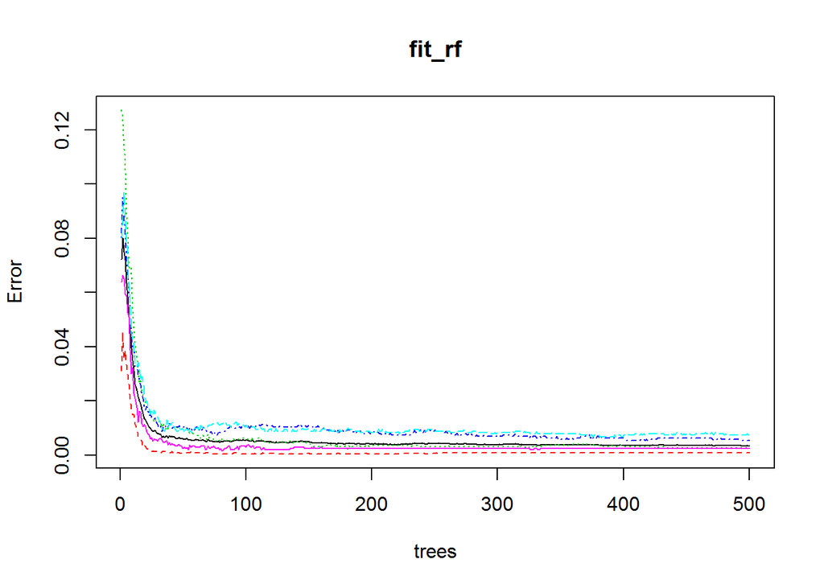

```r
plot(fit_rf)
```

```r
predict_rf<- predict(fit_rf,mytest)
conf_rf <- confusionMatrix(mytest$classe, predict_rf)
conf_rf
```

```
## Confusion Matrix and Statistics
##
##           Reference
## Prediction    A    B    C    D    E
##          A 2232    0    0    0    0
##          B    8 1509    1    0    0
##          C    0    3 1364    1    0
##          D    0    0    7 1279    0
##          E    0    0    0    4 1438
##
## Overall Statistics
##
##                Accuracy : 0.9969
##                  95% CI : (0.9955, 0.998)
##     No Information Rate : 0.2855
##     P-Value [Acc > NIR] : < 2.2e-16
##
##                   Kappa : 0.9961
##  Mcnemar's Test P-Value : NA
##
## Statistics by Class:
##
##                      Class: A Class: B Class: C Class: D Class: E
## Sensitivity            0.9964   0.9980   0.9942   0.9961   1.0000
## Specificity            1.0000   0.9986   0.9994   0.9989   0.9994
## Pos Pred Value         1.0000   0.9941   0.9971   0.9946   0.9972
## Neg Pred Value         0.9986   0.9995   0.9988   0.9992   1.0000
## Prevalence             0.2855   0.1927   0.1749   0.1637   0.1833
## Detection Rate         0.2845   0.1923   0.1738   0.1630   0.1833
## Detection Prevalence   0.2845   0.1935   0.1744   0.1639   0.1838
## Balanced Accuracy      0.9982   0.9983   0.9968   0.9975   0.9997
```

### Testing Set prediction

```r
predict(fit_rf, testData)
```

```
##  1  2  3  4  5  6  7  8  9 10 11 12 13 14 15 16 17 18 19 20
##  B  A  B  A  A  E  D  B  A  A  B  C  B  A  E  E  A  B  B  B
## Levels: A B C D E
```